# Applied Predictive Modeling

DATA 624 Group 2 Homework

John Grando, Kyle Gilde, Jonathan Hernandez, Albert Gilharry, Neil Hwang

January 27, 2019

# Overview

**For each response, and commentary, provided by us, the text will be bolded, as it appears here**

# Chapter 8 Regression Trees and Rule-Based Models

## Question 8.2

Use a simluation to show tree bias with different granuarities.  
**This question appears to be highlighting one of the big pitfalls of tree based models, which is *selection bias* that is well summarized by a quote in page 182 of the reading:**

*The danger occurs when a data set consists of a mix of informative and noise vairables, and the noise variables have many more splits than the informative variable. Then there is high probability that the noise variables will be chosen to split the top nodes of the tree. Pruning will produce either a tree with misleading structure or no tree at all.*

**The author also notes that as the presence of missing values increases, the selection of predictors becomse more biased.**

**In order to demonstrate this issue, we will use the classic mtcars dataset. Note, we have removed many of the high-granularity attributes in order to construct a sufficient example for this exercise.**

```r
set.seed(2)
data("mtcars")
#mtcars$mpg <- cut(mtcars$mpg, breaks = seq(10, 35, 5), labels = c(as.character(seq(10, 25, 5)), '30+'))
mtcars <- mtcars %>% select(cyl, vs, am, gear, carb)
summary(mtcars)
```

```
##       cyl              vs               am              gear
##  Min.   :4.000   Min.   :0.0000   Min.   :0.0000   Min.   :3.000
##  1st Qu.:4.000   1st Qu.:0.0000   1st Qu.:0.0000   1st Qu.:3.000
##  Median :6.000   Median :0.0000   Median :0.0000   Median :4.000
##  Mean   :6.188   Mean   :0.4375   Mean   :0.4062   Mean   :3.688
##  3rd Qu.:8.000   3rd Qu.:1.0000   3rd Qu.:1.0000   3rd Qu.:4.000
##  Max.   :8.000   Max.   :1.0000   Max.   :1.0000   Max.   :5.000
##       carb
##  Min.   :1.000
##  1st Qu.:2.000
##  Median :2.000
##  Mean   :2.812
##  3rd Qu.:4.000
##  Max.   :8.000
```

**Make train/test splitting for model analysis**

```r
mtcars_train_validate_list <- createDataPartition(y= mtcars$cyl, p=0.7, list = FALSE)
mtcars_train_test <- mtcars[mtcars_train_validate_list,]
mtcars_validate <- mtcars[-mtcars_train_validate_list,]
```

**For the constructed models, we will be predicting the number of cylinders a car has. However, we will first pre process inputs in order to get a set scale of data. This will be useful when we add in some noisy data later on, such that the same relative ranges are used.**

```r
mtcars_transformation <- preProcess(
  mtcars_train_test,
  method = list(center = colnames(mtcars %>% select(-cyl)),
       scale = colnames(mtcars %>% select(-cyl))))
mtcars_transformed <- predict(mtcars_transformation, mtcars_train_test)
summary(mtcars_transformed)
```

```
##       cyl              vs                am               gear
##  Min.   :4.000   Min.   :-0.9364   Min.   :-0.7842   Min.   :-0.8427
##  1st Qu.:4.000   1st Qu.:-0.9364   1st Qu.:-0.7842   1st Qu.:-0.8427
##  Median :6.000   Median :-0.9364   Median :-0.7842   Median :-0.8427
##  Mean   :6.261   Mean   : 0.0000   Mean   : 0.0000   Mean   : 0.0000
##  3rd Qu.:8.000   3rd Qu.: 1.0215   3rd Qu.: 1.2198   3rd Qu.: 0.5417
##  Max.   :8.000   Max.   : 1.0215   Max.   : 1.2198   Max.   : 1.9262
##       carb
##  Min.   :-0.9585
##  1st Qu.:-0.9585
##  Median :-0.4073
##  Mean   : 0.0000
##  3rd Qu.: 0.6949
##  Max.   : 2.8993
```

**Model and compute accuracy with no noise inserted**

```r
tree_model <- C5.0(formula = as.factor(mtcars_train_test$cyl) ~ .,
                        data = mtcars_train_test %>% select(-cyl))
tree_model
```

```
##
## Call:
## C5.0.formula(formula = as.factor(mtcars_train_test$cyl) ~ ., data
##  = mtcars_train_test %>% select(-cyl))
##
## Classification Tree
## Number of samples: 23
## Number of predictors: 4
##
## Tree size: 3
##
## Non-standard options: attempt to group attributes
```

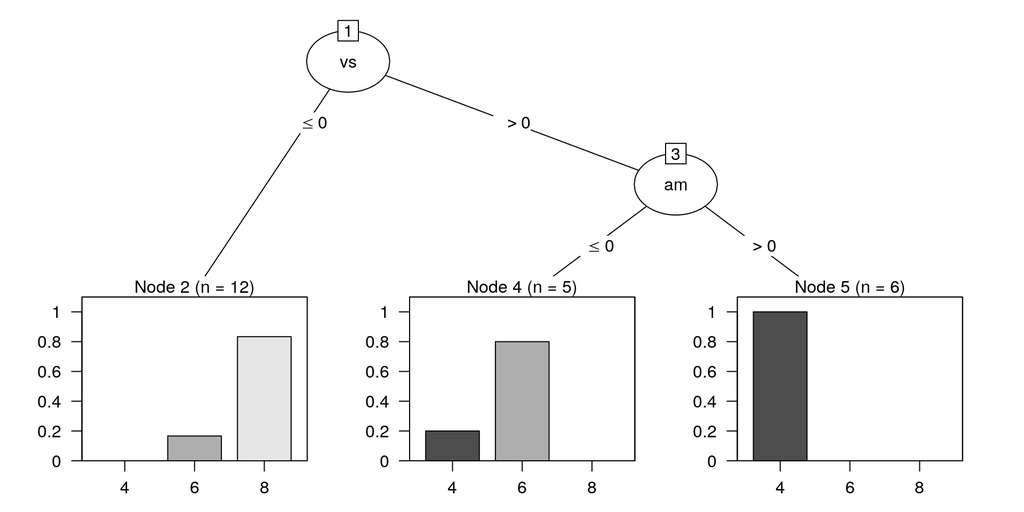

```r
plot(tree_model, roundint = FALSE)
```

```r
confusion_matrix <- table(predict(tree_model, mtcars_validate), mtcars_validate$cyl)
print(confusion_matrix)
```

```
##
##     4 6 8
##   4 1 0 0
##   6 2 0 0
##   8 1 1 4
```

```r
(accuracy <- sum(diag(confusion_matrix))/sum(confusion_matrix))
```

```
## [1] 0.5555556
```

**Now that we have calculated what the model should look like without noise, let’s add some additional columns, which should not be picked if there were no selection bias.**

**Add noisy columns of varying granularity and re-process data frame**

```r
#create
many_unique_values <- mtcars$am + floor(runif(nrow(mtcars), min = -1000, max = 1000)) / 1000
mid_unique_values <- mtcars$am + floor(runif(nrow(mtcars), min = -10, max = 10)) / 10
few_unique_values <- mtcars$am + floor(runif(nrow(mtcars), min = -2, max = 2)) / 2

#apply to base dataset
mtcars_noisy <- cbind(mtcars,
                    many_noise = many_unique_values,
                    mid_noise = mid_unique_values,
                    few_noise = few_unique_values)
#split
mtcars_noisy_train_test <- mtcars_noisy[mtcars_train_validate_list,]
mtcars_noisy_validate <- mtcars_noisy[-mtcars_train_validate_list,]
#center and scale
mtcars_noisy_transformation <- preProcess(
  mtcars_noisy_train_test,
  method = list(center = colnames(mtcars %>% select(-cyl)),
       scale = colnames(mtcars %>% select(-cyl))))
mtcars_noisy_transformed <- predict(mtcars_noisy_transformation, mtcars_noisy_train_test)
summary(mtcars_noisy_transformed)
```

```
##       cyl              vs                am               gear
##  Min.   :4.000   Min.   :-0.9364   Min.   :-0.7842   Min.   :-0.8427
##  1st Qu.:4.000   1st Qu.:-0.9364   1st Qu.:-0.7842   1st Qu.:-0.8427
##  Median :6.000   Median :-0.9364   Median :-0.7842   Median :-0.8427
##  Mean   :6.261   Mean   : 0.0000   Mean   : 0.0000   Mean   : 0.0000
##  3rd Qu.:8.000   3rd Qu.: 1.0215   3rd Qu.: 1.2198   3rd Qu.: 0.5417
##  Max.   :8.000   Max.   : 1.0215   Max.   : 1.2198   Max.   : 1.9262
##       carb           many_noise        mid_noise         few_noise
##  Min.   :-0.9585   Min.   :-0.7360   Min.   :-0.9000   Min.   :-1.0000
##  1st Qu.:-0.9585   1st Qu.: 0.0155   1st Qu.:-0.2500   1st Qu.:-0.5000
##  Median :-0.4073   Median : 0.3260   Median : 0.3000   Median : 0.0000
##  Mean   : 0.0000   Mean   : 0.3798   Mean   : 0.4304   Mean   : 0.1087
##  3rd Qu.: 0.6949   3rd Qu.: 0.8125   3rd Qu.: 1.0000   3rd Qu.: 0.7500
##  Max.   : 2.8993   Max.   : 1.8590   Max.   : 1.9000   Max.   : 1.5000
```

**Re-run tests and see what the effect is on the model trees**

```r
tree_noisy_model <- C5.0(formula = as.factor(mtcars_noisy_train_test$cyl) ~ .,
                        data = mtcars_noisy_train_test %>% select(-cyl))
tree_noisy_model
```

```
##
## Call:
## C5.0.formula(formula = as.factor(mtcars_noisy_train_test$cyl) ~ ., data
##  = mtcars_noisy_train_test %>% select(-cyl))
##
## Classification Tree
## Number of samples: 23
## Number of predictors: 7
##
## Tree size: 4
##
## Non-standard options: attempt to group attributes
```

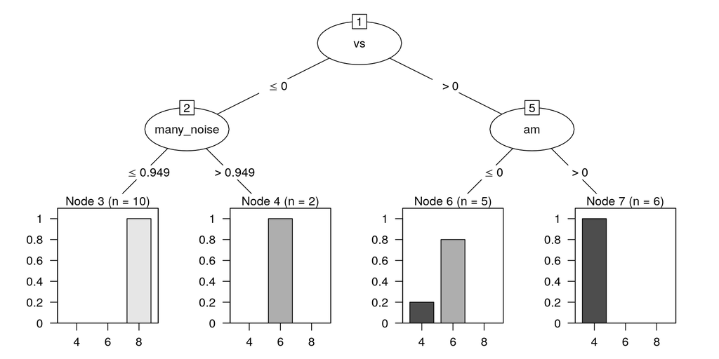

```r
plot(tree_noisy_model, roundint = FALSE)
```

```r
confusion_matrix <- table(predict(tree_noisy_model, mtcars_noisy_validate), mtcars_noisy_validate$cyl)
print(confusion_matrix)
```

```
##
##     4 6 8
##   4 1 0 0
##   6 2 0 2
##   8 1 1 2
```

```r
(accuracy <- sum(diag(confusion_matrix))/sum(confusion_matrix))
```

```
## [1] 0.3333333
```

**The results above show that selection bias has caused the tree to pick the `many_noise` attribute instead of splitting along the `am` attribute again in the lower nodes. This is not quite the example laid out in the quote above, but does still show the issue at hand. In fact, the validation accuracy has dropped from 55% to 33% showing why this type of issue is such a problem**